# Titanic Lime

```python
#importing libraries
# Disabling warnings
import warnings
warnings.simplefilter("ignore")

import pandas as pd
import pickle
import numpy as np
from sklearn.model_selection import train_test_split
#for label encoding
from sklearn.preprocessing import LabelEncoder
import xgboost as xgb
from xgboost.sklearn import XGBClassifier
from datetime import datetime

from xgboost import XGBClassifier
```

```python
#reading train data
train=pd.read_csv('..../train.csv')
```

```python
#checking size of data
print(train.shape)
```

```
(891, 12)
```

```python
train.head()
```

|  | PassengerId | Survived | Pclass | Name | Sex | Age | SibSp | Parch | Ticket | Fare | Cabin | Embarked |
| --- | --- | --- | --- | --- | --- | --- | --- | --- | --- | --- | --- | --- |
| 0 | 1 | 0 | 3 | Braund, Mr. Owen Harris | male | 22.0 | 1 | 0 | A/5 21171 | 7.2500 | NaN | S |
| 1 | 2 | 1 | 1 | Cumings, Mrs. John Bradley (Florence Briggs Th... | female | 38.0 | 1 | 0 | PC 17599 | 71.2833 | C85 | C |
| 2 | 3 | 1 | 3 | Heikkinen, Miss. Laina | female | 26.0 | 0 | 0 | STON/O2. 3101282 | 7.9250 | NaN | S |
| 3 | 4 | 1 | 1 | Futrelle, Mrs. Jacques Heath (Lily May Peel) | female | 35.0 | 1 | 0 | 113803 | 53.1000 | C123 | S |
| 4 | 5 | 0 | 3 | Allen, Mr. William Henry | male | 35.0 | 0 | 0 | 373450 | 8.0500 | NaN | S |

```python
#checking data types of the column
train.dtypes
```

```
PassengerId      int64
Survived         int64
Pclass           int64
Name            object
Sex             object
Age            float64
SibSp            int64
Parch            int64
Ticket          object
Fare           float64
Cabin           object
Embarked        object
dtype: object
```

```python
#checking unique values in a column
train.nunique()
```

```
PassengerId    891
Survived         2
Pclass           3
Name           891
Sex              2
Age             88
SibSp            7
Parch            7
Ticket         681
Fare           248
Cabin          147
Embarked         3
dtype: int64
```

```python
#checking null values in the column
train.isnull().sum()/train.shape[0]
```

```
PassengerId    0.000000
Survived       0.000000
Pclass         0.000000
Name           0.000000
Sex            0.000000
Age            0.198653
SibSp          0.000000
Parch          0.000000
Ticket         0.000000
Fare           0.000000
Cabin          0.771044
Embarked       0.002245
dtype: float64
```

### Pre Processing

```python
# filling up null values
```

```python
#replacing Age null value with mean
train['Age']=train['Age'].fillna(train['Age'].mean())
```

```python
#replacing Embarked with ffill( propagate last valid observation forward to next)
train.Embarked.fillna(method='ffill', inplace=True)
```

```python
##77% of cabin values are null so removing them, Also dropping Name and passengerID
train.drop(['PassengerId', 'Name', 'Cabin'], axis=1, inplace=True)
```

```python
##splitting X and Y

X=train.drop(['Survived'],axis=1)
y=train[['Survived']]
```

##### Encoding the values

We are doing label encoding since Lime doesn't work with one-hot encoding because you may get perturbations that create invalid inputs (and the explanation will be based on those). Let's say that you encode the variable 'sex' with one hot encoding, such that [1, 0] is male and [0, 1] is female. If you just use LIME, we have no way of knowing that [1, 1] is a nonsensical input, and will likely generate this combination (which will give your model something invalid).

```python
#finding columns which have dtype as object for encoding
objects_cols = X.select_dtypes("object").columns
objects_cols
```

```
Index(['Sex', 'Ticket', 'Embarked'], dtype='object')
```

```python
#finding index of categorical columns
categorical_features=[]
for col in objects_cols:
    categorical_features.append(X.columns.get_loc(col))
```

```python
categorical_features
```

```
[1, 5, 7]
```

```python
#encoding categorical variable and creating dictionary
categorical_names = {}
for feature in categorical_features:
    le = LabelEncoder()
    le.fit(X.iloc[:, feature].values)
    X.iloc[:, feature] = le.transform(X.iloc[:, feature])
    categorical_names[feature] = le.classes_
```

```python
categorical_names
```

[output not shown]

[output cut: 67 more lines]

[output not shown]

```python
X.head()
```

|  | Pclass | Sex | Age | SibSp | Parch | Ticket | Fare | Embarked |
| --- | --- | --- | --- | --- | --- | --- | --- | --- |
| 0 | 3 | 1 | 22.0 | 1 | 0 | 523 | 7.2500 | 2 |
| 1 | 1 | 0 | 38.0 | 1 | 0 | 596 | 71.2833 | 0 |
| 2 | 3 | 0 | 26.0 | 0 | 0 | 669 | 7.9250 | 2 |
| 3 | 1 | 0 | 35.0 | 1 | 0 | 49 | 53.1000 | 2 |
| 4 | 3 | 1 | 35.0 | 0 | 0 | 472 | 8.0500 | 2 |

```python
#splitting train and test data
```

```python
#splittinig data into 70-30(train and test)
X_train, X_test, y_train, y_test = train_test_split(X, y, test_size=0.3, random_state=1)
```

```python
#checking size of train and test
print(X_train.shape)
print(X_test.shape)
```

```
(623, 8)
(268, 8)
```

```python
#checking event rate in both dataset
print(y_train.sum()/len(y_train))
print(y_test.sum()/len(y_test))
```

```
Survived    0.364366
dtype: float64
Survived    0.429104
dtype: float64
```

```python
#fitting XGB models on our dataset

xgb_model=XGBClassifier(max_depth=4, learning_rate=0.1, n_estimators=125,seed=123)
xgb_model.fit(X_train.values,y_train.values)
```

```
XGBClassifier(max_depth=4, n_estimators=125, seed=123)
```

```python
#saving our model file using pickle
filename = '..../xgb_model.pkl'
pickle.dump(xgb_model, open(filename, 'wb'))
```

```python
#to load saved modek
filename = '...../xgb_model.pkl'
loaded_model = pickle.load(open(filename, 'rb'))
```

```python
#measuring accuracy of the model,importing library
from sklearn.metrics import confusion_matrix
from sklearn.metrics import accuracy_score

y_predicted = xgb_model.predict(X_test.values)
accuracy=accuracy_score(y_test, y_predicted)
tn, fp, fn, tp = confusion_matrix(y_test,y_predicted).ravel()
recall = tp/(tp+fn)
precision = tp/(tp+fp)

print("accuracy = {acc:0.3f},\nrecall = {recal:0.3f},\nprecision = {precision:0.3f}".format( acc=accuracy, recal=recall,precision=precision))
```

```
accuracy = 0.791,
recall = 0.643,
precision = 0.831
```

## LIME

```python
#importing the required library for lime
import lime
import lime.lime_tabular
```

### Setting up explainer

As opposed to lime_text.TextExplainer, tabular explainers need a training set. The reason for this is because it compute statistics on each feature (column). If the feature is numerical, it compute the mean and std, and discretize it into quartiles. If the feature is categorical, we compute the frequency of each value. these computed statistics are used for two things:

1. To scale the data, so that it can meaningfully compute distances when the attributes are not on the same scale
2. To sample perturbed instances - which it do by sampling from a Normal(0,1), multiplying by the std and adding back the mean.

#### 1. Descrtizer:

Discretize: if discretize_continuous is set to true all non-categorical features will be discretized into 'quartile' .by default quartile is use you can set it to 'decile' or 'entropy'. Discretization is used/preferred as our numeric values may be in different ranges. Thus we standardize the data, but then the meaning of the coefficients changes .

It's hard to think about double negatives (i.e. negative weight for a negative feature = positive contribution). We will show the both the result with and without discretization.

##### discretize_continuous=True

```python
explainer = lime.lime_tabular.LimeTabularExplainer(X_train.values[:,:],feature_names = X_train.columns,class_names=['not_survived','survived'],
                                                   categorical_features=categorical_features,
                                                   categorical_names=categorical_names,discretizer='decile',kernel_width=5,discretize_continuous=True,verbose=True)
```

```python
#getting the lime prediction for an observation
exp = explainer.explain_instance(X_train.iloc[1,:],xgb_model.predict_proba, num_features=4)
```

```
Intercept 0.15449455614924637
Prediction_local [0.76127416]
Right: 0.9500091
```

```python
#plotting in a notebook kind of format
exp.show_in_notebook(show_all=False)
exp.save_to_file('explanation.html')
```

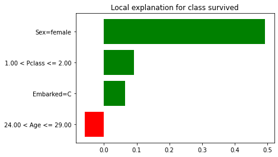

```python
#variable level contribution
%matplotlib inline
fig = exp.as_pyplot_figure(label=1)
```

```python
pd.DataFrame(exp.as_list(),columns=['Feature','Contribution'])
```

|  | Feature | Contribution |
| --- | --- | --- |
| 0 | Sex=female | 0.486252 |
| 1 | 1.00 < Pclass <= 2.00 | 0.091065 |
| 2 | Embarked=C | 0.075795 |
| 3 | 24.00 < Age <= 29.00 | -0.046333 |

```python
exp.intercept[1]+pd.DataFrame(exp.as_list())[1].sum()
```

```
0.761274161085735
```

```python
exp.as_map()
```

```
{1: [(1, 0.48625204786899684),
  (0, 0.09106544461384583),
  (7, 0.07579503893935471),
  (2, -0.04633292648570873)]}
```

##### discretize_continuous=False

```python
explainer = lime.lime_tabular.LimeTabularExplainer(X_train.values[:,:],feature_names = X_train.columns,class_names=['not_survived','survived'],
                                                   categorical_features=categorical_features,
                                                   categorical_names=categorical_names,kernel_width=5,discretize_continuous=False,verbose=True)
```

```python
#getting the lime prediction for an observation
exp = explainer.explain_instance(X_train.iloc[2,:],xgb_model.predict_proba, num_features=4)
```

```
Intercept 0.7502255827158602
Prediction_local [0.09037832]
Right: 0.049399726
```

```python
#plotting in a notebook kind of format
exp.show_in_notebook(show_all=False)
exp.save_to_file('explanation.html')
```

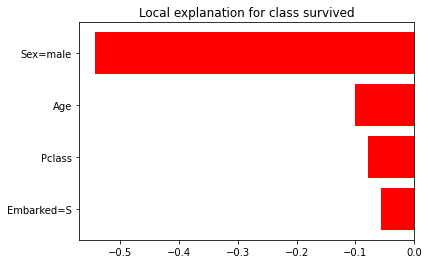

```python
#variable level contribution
%matplotlib inline
fig = exp.as_pyplot_figure(label=1)
```

```python
exp.as_list()
```

```
[('Sex=male', -0.5434211130320894),
 ('Age', -0.10005112019413362),
 ('Pclass', -0.07780906756685002),
 ('Embarked=S', -0.05626548173320968)]
```

```python
pd.DataFrame(exp.as_list(),columns=['Feature','Contribution'])
```

|  | Feature | Contribution |
| --- | --- | --- |
| 0 | Sex=male | -0.543421 |
| 1 | Age | -0.100051 |
| 2 | Pclass | -0.077809 |
| 3 | Embarked=S | -0.056265 |

```python
#calculating lime prediction value
```

```python
#getting indepedent  variables values
x=X_train.iloc[2,:]
#cretaing scaled version
scaled_x = (x - explainer.scaler.mean_) / explainer.scaler.scale_

#setting scaled value for categorical variable to be 1
#categorical_features indices of categorical feature
scaled_x[categorical_features]=1
#extracting  columns indiced
cols=[x[0] for x in exp.as_map()[1]]
#extracting their coeff
coeff=[x[1] for x in exp.as_map()[1]]
# getting prediction using pred= wixi + intercept
sum(scaled_x.iloc[cols]*coeff)+exp.intercept[1]
```

```
0.09037832188820683
```

```python
scaled_x
```

```
Pclass     -0.405272
Sex         1.000000
Age        -0.151129
SibSp       0.491588
Parch      -0.476460
Ticket      1.000000
Fare       -0.152797
Embarked    1.000000
Name: 874, dtype: float64
```

```python
# for all numeric variable and descrtization =False, you can use this get lime score
x=X_test.iloc[index,:]
scaled_x = (x - explainer.scaler.mean_) / explainer.scaler.scale_
cols=[x[0] for x in  exp.as_list()]
total=exp.intercept[1]
for col in cols:
    contr=scaled_x[col]*dict(exp.as_list())[col]
    total+=contr
```